# Peer-graded Assignment

Reproducible Templates for Analysis and Dissemination

Olaf Thelen-Presanis

2022-01-15

### Preparation

Loading packages used in this assignment.

```r
library(magrittr)
library(kableExtra)
```

*Note:* the source code of this publication can be found on [GitHub](https://github.com/othelen/CourseraReproducibleAssignment)

# Summary

This is the final, peer-graded assignment for the Coursera MOOC on ‘Reproducible Templates for Analysis and Dissemination’.

It contains

- a title $\checkmark$
- My Name as Author $\checkmark$
- The Date $\checkmark$
- A section of text summarizing the information in your document or slide presentation (keep this between 3-4 sentences) - *which is actually this section* $\checkmark$
- A bulleted list of 3 or more items (either numbered or unnumbered) $\checkmark$
- A plot of the built-in ‘pressure’ dataset $\checkmark$
- A table of the top 6 rows of the built-in ‘cars’ dataset $\checkmark$
- Apply a theme or style that changes the font, colors, or other formatting instead of the default template. (HINT: Remember to explore the options in the prettydoc, rmdformats, or revealjs packages) $\checkmark$

# Bulleted list

Poor sleep quality has been linked with the following symptoms:

- higher levels of negative mood
- physical symptoms such as insomnia
- stress
- use of medications
- persistent psychological distress (Glozier et al., 2010; Lund et al., 2010)

*Source:* [APA Style Website](https://apastyle.apa.org/style-grammar-guidelines/lists/bulleted)

back to top

# Pressure Data Set

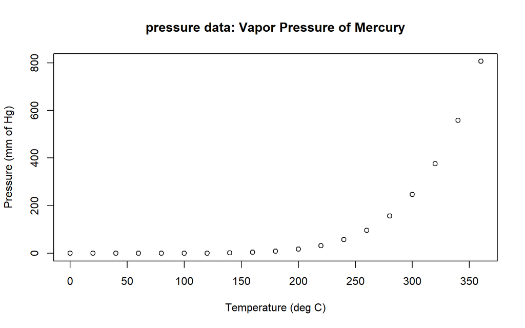

```r
plot(pressure, xlab = "Temperature (deg C)",
     ylab = "Pressure (mm of Hg)",
     main = "pressure data: Vapor Pressure of Mercury")
```

back to top

# Top rows of the `cars` dataset

```r
knitr:: kable(head(cars),
              caption = "Top 6 rows of cars dataset") %>%
  kable_styling(full_width = F)
```

Top 6 rows of cars dataset

| speed | dist |
| --- | --- |
| 4 | 2 |
| 4 | 10 |
| 7 | 4 |
| 7 | 22 |
| 8 | 16 |
| 9 | 10 |

back to top

# Change of design

As described by (Xie et al. 2021), useful templates come in various packages. One is the **rmdformats** package (Barnier 2021), which “provides a number of templates that pass different custom styling functions to the output option” [^1].

I am using the *downcute* template with the following `YAML header` settings:

```
output:
  rmdformats::downcute:
    self_contained: true
    default_style: "dark"
    downcute_theme: "default"
```

back to top

# References

Barnier, Julien. 2021. Rmdformats: HTML Output Formats and Templates for Rmarkdown Documents. https://github.com/juba/rmdformats.  
Yihui Xie, Christophe Dervieux, Emily Riederer. 2021. R Markdown Cookbook.  
https://bookdown.org/yihui/rmarkdown-cookbook/

[^1]: Xie et al. 2021, Chapter 16.8.1